# Homework 8 Solution

## Disclaimer

This homework solution is for the sole benefit of students taking Stat 220 from Prof. Bastola during Fall term 2022. Dissemination of this solution to people who are not registered for this course is not permitted and will be considered grounds for Academic Dishonesty for the all individuals involved in the giving and receiving of the solution.

## Problem 1: Random classifiers

Suppose you have $n$ observations and you would like to construct a classifier to predict positive outcomes. We know that $n_N$ are actually negative cases and $n_P$ are actually positive cases.

Suppose we are a lazy data scientist and don’t actually build a model with predictors to classify our cases. Instead, we use a fair coin to classify negative and positive cases! This “coin classifier” will result in an even split between *expected* positive and negative predictions:
$$\hat{n}_N = \hat{n}_P = \dfrac{n}{2}$$
Using the same logic, half of the actual negatives will be positives and positives:
$$TN = FP = \dfrac{n_N}{2}$$
and half of the actual positives will be positives and negatives:
$$FN = TP = \dfrac{n_P}{2}$$

| confusion matrix | truth: negative | truth positive | total |
| --- | --- | --- | --- |
| predict negative | $TN=\dfrac{n_N}{2}$ | $FN= \dfrac{n_P}{2}$ | $\hat{n}_N =\dfrac{n}{2}$ |
| predict positive | $FP=\dfrac{n_N}{2}$ | $TP= \dfrac{n_P}{2}$ | $\hat{n}_P =\dfrac{n}{2}$ |
| total | $n_N$ | $n_P$ | $n$ |

### a.

Use the “coin classifier” confusion matrix above to compute accuracy, precision, sensitivity, and specificity for this fair coin prediction method.

*Answer:* With a fair coin flip predicting positives, the accuracy will be 50%.
$$accuracy = \dfrac{TN + TP}{n} = \dfrac{0.5n_N + 0.5n_P}{n} = 0.5
\dfrac{n_N+n_P}{n} = 0.5$$
Precision will be equal to the rate of positives in the sample since 50% of the positives are correctly predicted and 50% of the overall sample is predicted to be positives:
$$precision = \dfrac{TP}{\hat{n}_P} = \dfrac{0.5n_P}{0.5n}
= \dfrac{n_P}{n}$$
Sensitivity will be 50% since that is the rate at which we correctly predict positives:
$$Sensitivity = \dfrac{TP}{n_P} = \dfrac{0.5n_P}{n_P} = 0.5$$
Specificity will also be 50% since that is the rate at which we correctly predict negatives:
$$Specificity = \dfrac{TN}{n_N} = \dfrac{0.5n_N}{n_N} = 0.5$$

### b.

Consider another classification method that doesn’t actually build a model with predictors to classify our cases. Instead, we now predict all cases to be positive! (e.g. a biased coin that lands “positive” with probability 1)

Construct the confusion matrix for this classifier and compute accuracy, precision, sensitivity, and specificity.

*Answer:* Here all cases are positive, so $TN = 0$ (no negatives predicted) and $FN = 0$ (no negatives predicted). All negative cases are predicted positive, so $FP = n_N$ and all positive cases are predicted positive, so $TP = n_P$.

| confusion matrix | truth negative | truth positive | total |
| --- | --- | --- | --- |
| predict negative | $TN=0$ | $FN= 0$ | $\hat{n}_N =0$ |
| predict positive | $FP=n_N$ | $TP= n_P$ | $\hat{n}_P =n$ |
| total | $n_N$ | $n_P$ | $n$ |

With a probability $p$ predicting positives, the accuracy will be the rate of positives in the sample:
$$accuracy = \dfrac{TN + TP}{n} = \dfrac{0 + n_P}{n} = \dfrac{n_P}{n}$$
Precision will be equal to the rate of positives in the sample:
$$precision = \dfrac{TP}{\hat{n}_P} = \dfrac{n_P}{n}$$
Sensitivity will be $100$% since that is the rate at which we correctly predict positives:
$$Sensitivity = \dfrac{TP}{n_P} = \dfrac{n_P}{n_P} = 1$$
Specificity will be 0% since that is the rate at which we correctly predict negatives:
$$Specificity = \dfrac{TN}{n_N} = \dfrac{0}{n_N} = 0$$

### c.

Under what conditions in part (b) will accuracy of this classifier be highest? Under what conditions in part (b) will accuracy of this classifier be lowest?

*Answer:* Accuracy is the rate of positive cases in the data, $\dfrac{n_P}{n}$. So when we have a lot of positive cases in the data, predicting all cases to be positive will yield high accuracy. But when we have few positive cases the accuracy will be low.

### d.

Describe the trade-off in part (b) in specificity vs sensitivity. What would these values be if instead of classifying every case as positive, you classified all cases as negative?

*Answer:* We have sensitivity of 1 because we are finding all true positive cases when predicting all positives. But we have specificity of 0 because no true negatives are correctly predicted. If we reverse the classification and predict all negative cases, the opposite will occur with specificy of 1 and sensitivity of 0.

## Problem 2: Spam using k-nn

This example looks at a data set of about 4600 emails that are classified as spam or not spam, along with over 50 variables measuring different characteristic of the email. Details about these variables are found on the [Spambase example](http://archive.ics.uci.edu/ml/datasets/Spambase) on the machine learning data archive. The dataset linked to below is a slightly cleaned up version of this data. The only extra column in the data is `rgroup` which is a randomly assigned grouping variable (groups 0 through 99) which we will eliminate from the data.

Read the data in using the commands below to create a response `class` variable that contains the factor levels `spam` and `nonspam` with `spam` the first level.

```r
> # tsv = tab separated values!
> spam <- read_delim("https://raw.githubusercontent.com/deepbas/statdatasets/main/spam.txt",
+         delim="\t")
>
> # some clean up
> spam <- spam %>%
+   mutate(class = fct_recode(
+     spam,
+     spam = "spam" ,
+     nonspam = "non-spam"), # rename levels because caret doesn't like "non-spam"
+     class = fct_relevel(class, "spam") # make "spam" the first level (our "positive")
+     ) %>%
+   select(-rgroup, -spam) # don't need random group variable and  spam variable
> levels(spam$class)  # verify "spam" is level 1
[1] "spam"    "nonspam"
```

What proportion of cases are spam in this data set? The variable `class` is the true classification of an email.

*answer:*

```r
> spam %>%
+   count(class) %>%
+   mutate(n/sum(n))
```

| class | n | n/sum(n) |
| --- | --- | --- |
| spam | 1813 | 0.3940448 |
| nonspam | 2788 | 0.6059552 |

### b.

We want to fit a k-nn classifier for `spam` using the 57 quantitative predictors (columns 1-57) from the spam data to an 80%/20% training and test set split. Create the training and test sets to do this.

Use the following seed and the `sample` command generate training data (this *should* mean your train/test split should be the same as the solution key!):

```r
> set.seed(757302859)  # set a seed
```

*answer:*

```r
> set.seed(757302859)  # set a seed
>
> spam_split <- initial_split(spam, prop = 0.80)
> # Create training data
> spam_train <- spam_split %>%
+                     training()
> # Create testing data
> spam_test <- spam_split %>%
+                     testing()
```

### c.

Make a recipe for fitting k nearest-neighbor algorithm to the training data by inputting the formula and preprocessing steps.

```r
> spam_recipe <- recipe(class ~ ., data = spam_train) %>%
+   step_scale(all_predictors()) %>%
+   step_center(all_predictors()) %>%
+   prep()
```

### d.

Specify the nearest neighbor model to fit a classification model using 10 neighbors.

```r
> spam_knn_spec <- nearest_neighbor(mode = "classification",
+                              engine = "kknn",
+                              weight_func = "rectangular",
+                              neighbors = 10)
```

### e.

Define the workflow object feeding in the recipe and model specification. Then, fit the model to the training data. *answer:*

```r
> spam_workflow <- workflow() %>%
+   add_recipe(spam_recipe) %>%
+   add_model(spam_knn_spec)
>
> spam_fit <- fit(spam_workflow, data = spam_train)
```

### f.

Evaluate the model on the test datasetand predict `class` for the test data set.

```r
> test_features <- spam_test  %>% select(-class)
> spam_pred <- predict(spam_fit, test_features, type = "raw")
> spam_results <- spam_test %>%
+   select(class) %>%
+   bind_cols(predicted = spam_pred)
```

### g.

Compute the accuracy, sensitivity, specificity and precision for predicting test set responses. Which rate(s) would you like to be high as a user of this spam filter?

*Answer:*

As someone who rarely looks in my spam folder, I want to make sure that there are very few “false positives”, meaning very few non-spam emails that get dumped in my spam folder. So I want high specificity and high precision in the filter.

```r
> custom_metrics <- metric_set(accuracy, sens, spec, ppv)
> metrics <- custom_metrics(spam_results,
+                truth = class,
+                estimate = predicted)
> metrics <- metrics %>% select(-.estimator)
```

[output not shown]

### h.

Use the `tidymodels` package to do 10-fold cross validation as follows:

After running `train` to produce the 10-fold CV results (this could take ~1 minute), use the `results` from your `train` object to get the training set cross-validated estimates of the accuracy, precision, sensitivity and specificity of your final (“best”) classifier.

And use the following seed before running your `train` command:

```r
> set.seed(30498492)
```

*answer*

Run CV for knn:

```r
> spam_recipe_new <- recipe(class ~ ., data = spam_train) %>%
+   step_scale(all_predictors()) %>%
+   step_center(all_predictors())%>%
+   prep()
```

```r
> knn_spec <- nearest_neighbor(
+   weight_func = "rectangular",
+   neighbors = tune()
+ ) %>%
+   set_engine("kknn") %>%
+   set_mode("classification")
```

```r
> spam_vfold <- vfold_cv(spam_train, v = 10, strata = class)
```

```r
> k_vals <- tibble(neighbors = seq(from = 1, to = 30, by = 1))
```

```r
> knn_fit <- workflow() %>%
+   add_recipe(spam_recipe_new) %>%
+   add_model(knn_spec) %>%
+   tune_grid(
+     resamples = spam_vfold,
+     grid = k_vals,
+     metrics = custom_metrics
+     )
```

### i.

Use the `results` object from your CV fit from part (i) to plot the accuracy, precision, sensitivity and specificity for the values of $k$ that you tuned over. Comment on which neighborhood sizes are “best” in terms of these four metrics (your answer may depend on the metric).

*answer*

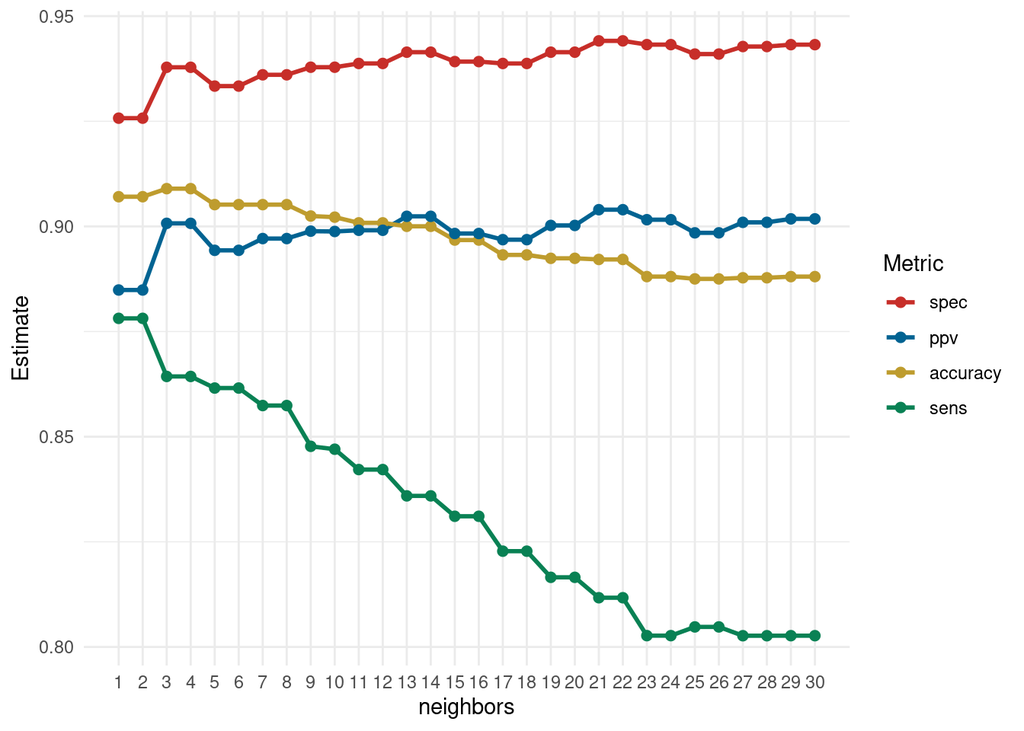

```r
> cv_metrics <- collect_metrics(knn_fit)
> final.results <- cv_metrics %>%  mutate(.metric = as.factor(.metric)) %>%
+   select(neighbors, .metric, mean)
>
> final.results %>%
+   ggplot(aes(x = neighbors, y = mean, color = forcats::fct_reorder2(.metric, neighbors, mean))) +
+   geom_line(size = 1) +
+   geom_point(size = 2) +
+   theme_minimal() +
+   scale_color_wsj() +
+   scale_x_continuous(breaks = seq(1,30)) +
+   theme(panel.grid.minor.x = element_blank()) +
+   labs(color='Metric', y = "Estimate")
```